# Assignment_4

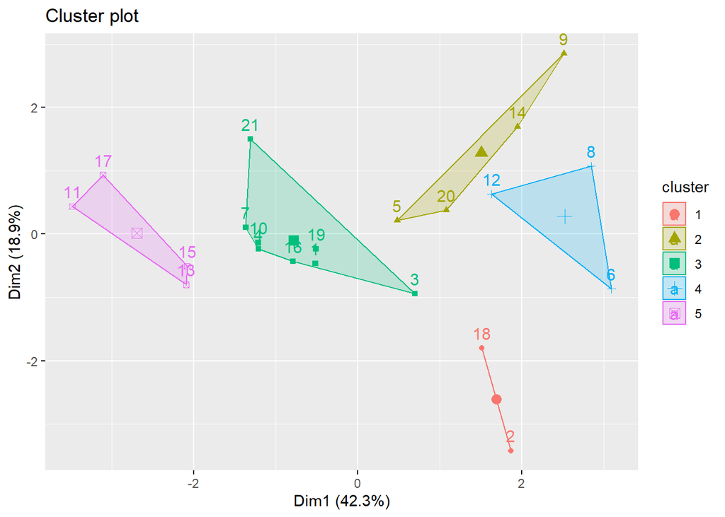

```r
#Visualing the Cluster
fviz_cluster(k,data = pharm.norm.Pharm)
```

Interpretation - The k-means plot provides an optimal representation of clusters, grouping together points that are close to each other into the same cluster. It offers a clear visualization of the dataset’s structure, making it easier to analyze the inherent patterns within the data.

**DBSCAN Clustering**

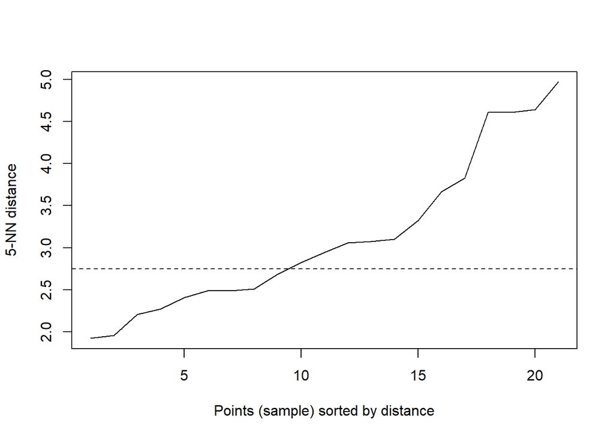

```r
set.seed(123)

#Generating kNN distance plot for the normalized dataset using k=5
dbscan::kNNdistplot(pharm.norm.Pharm,k=5)


abline(h = 2.75, lty = "dashed")
```

Therefore, the optimal value for epsilon, which is 2.75 (knee-point), indicates that we can build a DBSCAN model using this value.

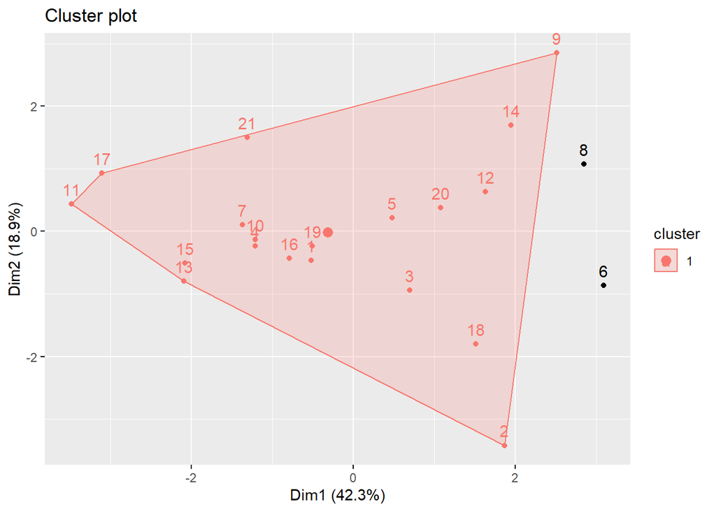

```r
db= dbscan::dbscan(pharm.norm.Pharm,eps=2.75,minPts = 2)
fviz_cluster(db,pharm.norm.Pharm)
```

Interpretation - The DBSCAN method appears inappropriate for clustering the provided data as it predominantly groups all data points into a single cluster. Moreover, selecting a smaller value for epsilon results in most points being classified as outliers. Therefore, DBSCAN is not an optimal method for this dataset.

Justification - The rationale behind our choices stems from the absence of explicit weightage for variables, leading us to normalize the data and accord equal significance to all factors. Through rigorous experimentation with various clustering methods, the k-means approach emerged as the most effective for our dataset, providing a clearer clustering depiction wherein closely positioned data points are grouped together within clusters. To determine the appropriate number of clusters, we utilized techniques such as the elbow method and distribution plots to identify optimal values for ‘k’ and ‘eps’, ensuring a comprehensive analysis of the data.

**Solution 2**

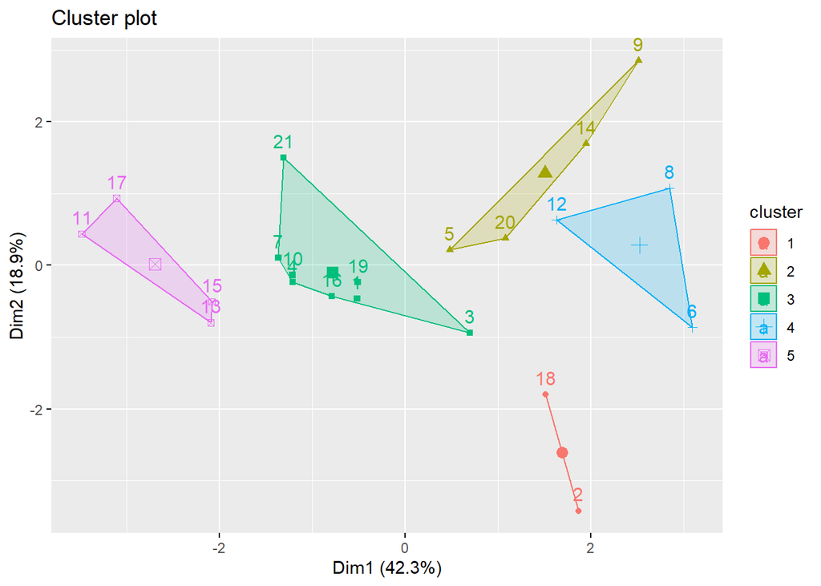

```r
fviz_cluster(k,data = pharm.norm.Pharm)
```

In terms of the numerical values used in clustering, the data points within the same k-means clusters exhibit proximity to each other, contrasting with those in distinct groups. Observing these clusters allows for a clearer interpretation of the data.

**Solution 3**

```r
pharm.norm.Pharm[c(6,8,12),]
```

```
## # A tibble: 3 × 9
##   Market_Cap  Beta PE_Ratio    ROE    ROA Asset_Turnover Leverage Rev_Growth
##        <dbl> <dbl>    <dbl>  <dbl>  <dbl>          <dbl>    <dbl>      <dbl>
## 1     -0.695 2.28    0.149  -1.45  -1.71          -0.461   -0.750    -1.50
## 2     -0.977 1.26    0.0330 -0.112 -1.17          -0.461    3.74     -0.633
## 3     -0.939 0.484  -0.341  -0.291 -0.698         -0.461    1.11      0.0560
## # ℹ 1 more variable: Net_Profit_Margin <dbl>
```

This particular cluster displays high Beta values alongside an average PE-ratio, while all other variables fall below average levels. However, the variables leverage and Rev_growth exhibit a mixture of values within this cluster.

```r
pharm.norm.Pharm[c(2,18),]
```

```
## # A tibble: 2 × 9
##   Market_Cap   Beta PE_Ratio    ROE    ROA Asset_Turnover Leverage Rev_Growth
##        <dbl>  <dbl>    <dbl>  <dbl>  <dbl>          <dbl>    <dbl>      <dbl>
## 1    -0.854  -0.451     3.50 -0.855 -0.942          0.923   0.0183     -0.381
## 2    -0.0241 -0.490     1.90 -0.815 -0.905         -0.461  -0.302       0.147
## # ℹ 1 more variable: Net_Profit_Margin <dbl>
```

Within this cluster, the PE ratio stands out as notably high, while the remaining variables fall below average levels. Nonetheless, the cluster also exhibits mixed values for leverage and rev_growth.

**Cluster 3**

```r
pharm.norm.Pharm[c(1,3,4,7,10,16,19,21),]
```

```
## # A tibble: 8 × 9
##   Market_Cap    Beta PE_Ratio     ROE    ROA Asset_Turnover Leverage Rev_Growth
##        <dbl>   <dbl>    <dbl>   <dbl>  <dbl>          <dbl>    <dbl>      <dbl>
## 1      0.184 -0.801   -0.0467  0.0401  0.242          0      -0.212      -0.528
## 2     -0.876 -0.256   -0.292  -0.722  -0.510          0.923  -0.404      -0.572
## 3      0.170 -0.0223  -0.243   0.106   0.918          0.923  -0.750       0.147
## 4     -0.108 -0.100   -0.709   0.597   0.862          0.923  -0.0201     -0.966
## 5      0.276 -1.35     0.149   0.345   0.561         -0.461  -0.0713     -0.648
## 6      0.665 -1.31    -0.237  -0.523   0.129         -0.923  -0.673      -1.45
## 7     -0.402 -0.0612  -0.402  -0.212   0.523          0.461  -0.750      -0.435
## 8     -0.161  0.406   -0.758   1.93    0.542         -0.461   0.684      -1.18
## # ℹ 1 more variable: Net_Profit_Margin <dbl>
```

This specific cluster displays notably high net profit values, although the remaining variables exhibit mixed values.

```r
pharm.norm.Pharm[c(11,17,15,13),]
```

```
## # A tibble: 4 × 9
##   Market_Cap   Beta PE_Ratio   ROE   ROA Asset_Turnover Leverage Rev_Growth
##        <dbl>  <dbl>    <dbl> <dbl> <dbl>          <dbl>    <dbl>      <dbl>
## 1       1.10 -0.684   -0.457 2.46  1.84           1.38    -0.314      0.769
## 2       2.42  0.484   -0.114 1.31  1.63           0.461   -0.545      1.10
## 3       1.28 -0.256   -0.402 0.981 0.843          1.85    -0.391      0.360
## 4       1.98 -0.256    0.180 0.186 1.09           0.923   -0.622     -0.362
## # ℹ 1 more variable: Net_Profit_Margin <dbl>
```

```r
pharm.norm.Pharm[c(5,9,14,20),]
```

```
## # A tibble: 4 × 9
##   Market_Cap   Beta PE_Ratio    ROE    ROA Asset_Turnover Leverage Rev_Growth
##        <dbl>  <dbl>    <dbl>  <dbl>  <dbl>          <dbl>    <dbl>      <dbl>
## 1     -0.179 -0.801   -0.329 -0.265 -0.566         -0.461   -0.314       1.22
## 2     -0.970  2.16    -1.34  -0.709 -1.02          -1.85     0.620       1.89
## 3     -0.963  0.874    0.192 -0.968 -0.961         -1.85     0.441       1.54
## 4     -0.928 -1.11    -0.433 -1.03  -0.698         -0.923   -0.494       1.43
## # ℹ 1 more variable: Net_Profit_Margin <dbl>
```

This particular cluster demonstrates low values across Marketcap, PE-ratio, ROE, ROA, and Net_Profit, while the remaining variables exhibit mixed values.

- Creating barchart to examine patterns in variables that were not utilized in the clustering process.

**Evaluating the recommendations of different clusters.**

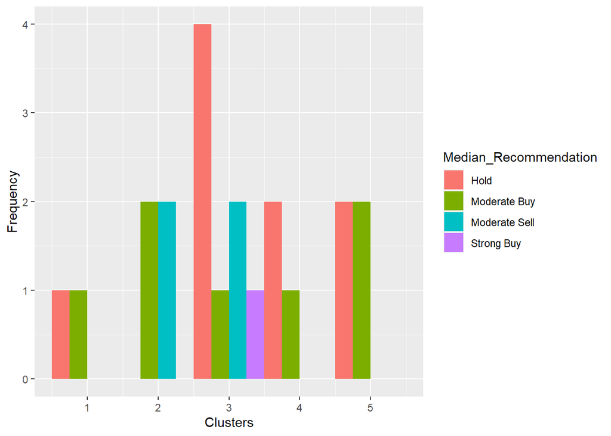

```r
Pharm.2 <- Pharm %>%
  select(c(1, 12, 13, 14)) %>%
  mutate(cluster = k$cluster)

# Creating a bar plot to visualize the frequency of median recommendations within clusters.
ggplot(Pharm.2, aes(x = cluster, fill = Median_Recommendation)) +
  geom_histogram(position = "dodge", binwidth = 1, aes(y = after_stat(count))) +
  labs(x = "Clusters", y = "Frequency")
```

**Evaluating countries of clusters**

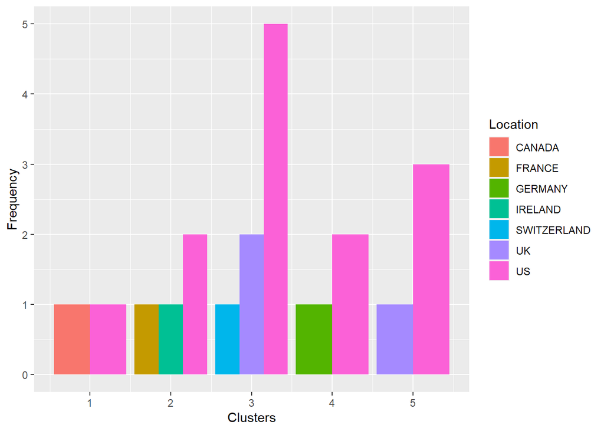

```r
# Creating a bar plot to visualize the distribution of locations across clusters.
ggplot(Pharm.2, aes(cluster, fill = Location)) +
  geom_bar(position = 'dodge') +
  labs(x = 'Clusters', y = 'Frequency')
```

**stock-exchanges of clusters**

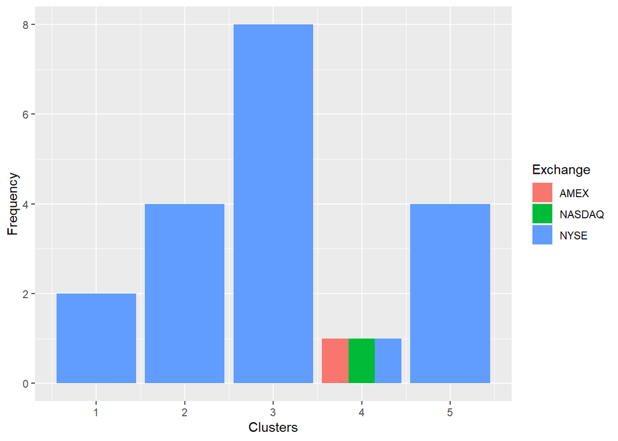

```r
ggplot(Pharm.2,mapping = aes(cluster,fill=Exchange))+
  geom_bar(position = 'dodge') +
  labs(x='Clusters',y='Frequency')
```

Interpretation and Observed Pattern

The observed pattern indicates that the recommendations vary based on the geographical presence and exchange listing of the companies. Companies with diversified operations and listings tend to have different recommendations compared to those operating in specific regions or listed on a single exchange.

**Solution 4**